[figure not shown]

# Guitar fret distance calculation

Playing classical guitar I hardly pay attention to the position of the frets. However it is interesting to know why frets are located on specific fretboard positions.

Frets are the raised, metals strips placed on the neck of the guitar. The first fret is the strip closest to the guitar's headstock. Frets are fixed on the neck's fretboard and divide the neck into fixed segments at intervals related to a musical framework. Each fret represents one semitone in the standard western system, in which one octave is divided into twelve semitones. Moving from the nut each fret raises the note by such a semitone until a full octave is reached at the 12th fret. It is this 12th fret that divides the distance between nut (or sometimes 0-fret) and bridge, the scale length, exactly in half.

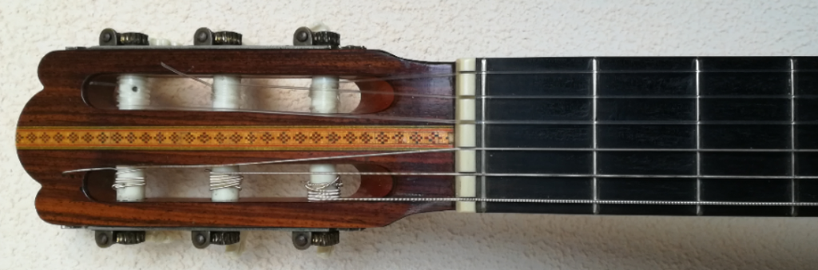

```python
import matplotlib.pyplot as plt
from IPython.display import Image
Image(filename='headstockMozzaniZeroFret.PNG', width=400, height=40)
```

Headstock and fretboard with 0-fret.

### 12-TET

Dividing the octave into 12 parts with a ratio of distances between two frets of $\sqrt[12]{2}$ is called 12-tone equal temperament, abbreviated 12-TET. On a logarithmic scale all 12 parts are equal.  
The exact calculation of equal temperament is attributed to Zhu Zaiyu (China, 1584) and Simon Stevin (Flanders, 1585).

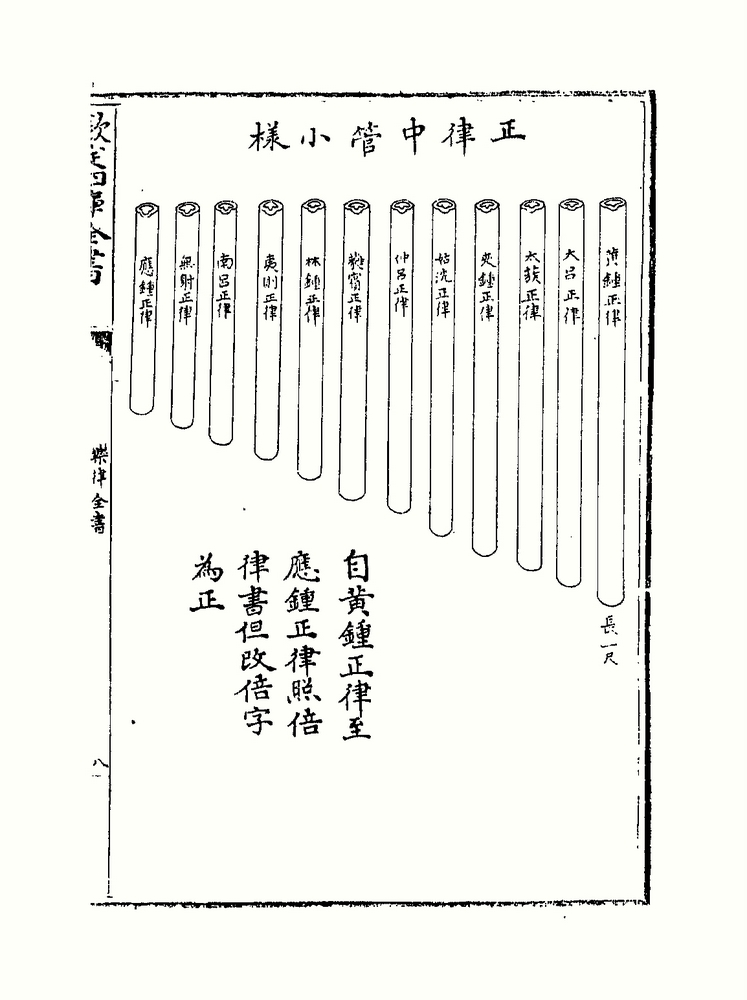

```python
Image(filename='ZhuZaiyuEqualTemperamentPitch.jpg', width=300, height=30)
```

Zhu Zaiyu's equal temperament (source Wikipedia)

### Calculator fret positions

Calulating the fret positions is quite easy. Presented are two ways to do so.

- Using the equal temperament constant of 17.817. This constant is derived from the ratio as follows: $\frac{scalelength}{scalelength - (\frac{scalelength}{\sqrt[12]{2}})}$
- Using the ratio $\sqrt[12]{2}$ between two frets.

```python
dash = '-' * 65
print(dash)
print('{:<5s}{:>30s}{:>30s}'.format('Fret', 'Nut distance (constant) [mm]','Nut distance (ratio) [mm]'))
print(dash)
#
scale_length = 650
#constant = 17.817
constant = scale_length / (scale_length - (scale_length / 2**(1/12)))
from_nut = 0
for fret in range(1,13):
    # method using constant
    from_nut = (scale_length - from_nut)/constant + from_nut
    # method using ratio
    from_nut_ratio = scale_length - (scale_length / (2**(fret/12)))
    print('{:<5d}{:>30.18f}{:>30.18f}'.format(fret,from_nut,from_nut_ratio))
```

```
-----------------------------------------------------------------
Fret   Nut distance (constant) [mm]     Nut distance (ratio) [mm]
-----------------------------------------------------------------
1             36.481696756899282263         36.481696756899282263
2             70.915833208779559982         70.915833208779417873
3            103.417330085085694691        103.417330085085495739
4            134.094658110335359424        134.094658110335217316
5            163.050200015078729621        163.050200015078530669
6            190.380592228744347949        190.380592228744148997
7            216.177047394739076935        216.177047394738849562
8            240.525658784166495252        240.525658784166182613
9            263.507687624115931158        263.507687624115646940
10           285.199834299454096254        285.199834299453755193
11           305.674494333229347376        305.674494333229063159
12           325.000000000000341061        325.000000000000000000
```

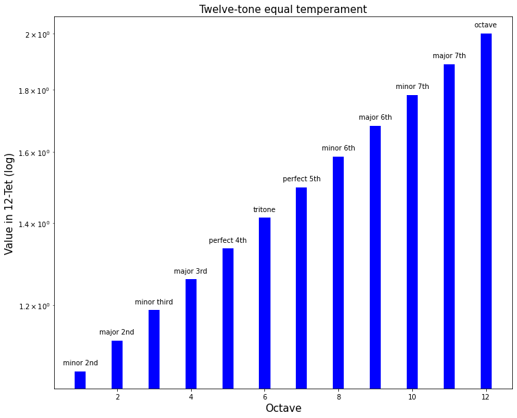

```
[1.0594630943592953, 1.122462048309373, 1.189207115002721, 1.2599210498948732, 1.3348398541700344, 1.4142135623730951, 1.4983070768766815, 1.5874010519681994, 1.681792830507429, 1.7817974362806785, 1.887748625363387, 2.0]
```

```python
fig, ax = plt.subplots(figsize=(12,10))
parts12Tet=[]
for tone in range(1,13):
    parts12Tet.append(2**(tone/12))
labels = ['minor 2nd', 'major 2nd', 'minor third', 'major 3rd', 'perfect 4th', 'tritone', 'perfect 5th', 'minor 6th', 'major 6th', 'minor 7th', 'major 7th', 'octave']
bar_plot=plt.bar(range(1,13), parts12Tet, width=.3, color='b')
for i, rect in enumerate(bar_plot):
    height = rect.get_height()
    ax.text(rect.get_x() + rect.get_width()/2., 1.01*height,
            labels[i],
            ha='center', va='bottom', rotation=0)
plt.title('Twelve-tone equal temperament', fontsize=15)
plt.xlabel('Octave', fontsize=15)
plt.yscale('log')
plt.ylabel('Value in 12-Tet (log)', fontsize=15)
plt.show()
print(parts12Tet)
```

Zhu Zaiyu upside down 😉

An extensive description on calculating fret positions can be found on [Liutaio Mottola's](https://www.liutaiomottola.com/formulae/fret.htm) website.